# Problem Statement: Concrete Strength Prediction

### Objective

To predict the concrete strength using the data available in file concrete_data.xls. Apply feature engineering and model tuning to obtain 80% to 95% of R2score.

```python
# Let's try to ignore unnecessary warninngs
import warnings
warnings.filterwarnings('ignore')
from mpl_toolkits.mplot3d import Axes3D
```

## Import Libs

```python
import math
from scipy.stats import randint as sp_randint

import pandas as pd # For data processing, CSV file IO (e.g. pd.read_csv())
import numpy as np # for Linear Algebra
import pandas_profiling as pf # Generates profile reports from pandas DataFrame

# importing machine learning parameters and classifiers
from sklearn import preprocessing # provides several common utility functions and transformer classes
# to change to change raw feature vectors into representation more suitable for downstream estimators
from sklearn import metrics #  includes score functions, performance metrics and pairwise metrics and distance computations
from sklearn.metrics import classification_report, confusion_matrix, accuracy_score # Build a text report showing the main classification metrics,Compute confusion matrix to evaluate the accuracy of a classification.
from sklearn.model_selection import train_test_split # splits data into random train and test subsets
from sklearn.preprocessing import LabelEncoder
from sklearn.metrics import mean_squared_error
from sklearn.model_selection import cross_val_score

#Visulization Libraries
from yellowbrick.classifier import ClassificationReport, ROCAUC
from IPython.display import Markdown, display
import seaborn as sns # data visualization lib based upon matplotlib
import matplotlib.pyplot as plt # is a state-based interface to matplotlib. It provides a MATLAB-like way of plotting
%matplotlib inline
# a magic function which sets the backend of matplotlib to the 'inline' backend
```

#### Load Data

```python
dfConcreteData = pd.read_csv("concrete.csv")
dfConcreteData.head(10)
```

|  | cement | slag | ash | water | superplastic | coarseagg | fineagg | age | strength |
| --- | --- | --- | --- | --- | --- | --- | --- | --- | --- |
| 0 | 141.3 | 212.0 | 0.0 | 203.5 | 0.0 | 971.8 | 748.5 | 28 | 29.89 |
| 1 | 168.9 | 42.2 | 124.3 | 158.3 | 10.8 | 1080.8 | 796.2 | 14 | 23.51 |
| 2 | 250.0 | 0.0 | 95.7 | 187.4 | 5.5 | 956.9 | 861.2 | 28 | 29.22 |
| 3 | 266.0 | 114.0 | 0.0 | 228.0 | 0.0 | 932.0 | 670.0 | 28 | 45.85 |
| 4 | 154.8 | 183.4 | 0.0 | 193.3 | 9.1 | 1047.4 | 696.7 | 28 | 18.29 |
| 5 | 255.0 | 0.0 | 0.0 | 192.0 | 0.0 | 889.8 | 945.0 | 90 | 21.86 |
| 6 | 166.8 | 250.2 | 0.0 | 203.5 | 0.0 | 975.6 | 692.6 | 7 | 15.75 |
| 7 | 251.4 | 0.0 | 118.3 | 188.5 | 6.4 | 1028.4 | 757.7 | 56 | 36.64 |
| 8 | 296.0 | 0.0 | 0.0 | 192.0 | 0.0 | 1085.0 | 765.0 | 28 | 21.65 |
| 9 | 155.0 | 184.0 | 143.0 | 194.0 | 9.0 | 880.0 | 699.0 | 28 | 28.99 |

## About Dataset and variable

Data Type: multivariate

Abstract: Concrete is the most important material in civil engineering. The concrete compressive strength is a highly nonlinear function of age and ingredients. These ingredients include cement, blast furnace slag, fly ash, water, superplasticizer, coarse aggregate, and fine aggregate.

Variable Information:

Given is the variable name, variable type, the measurement unit and a brief description. The concrete compressive strength is the regression problem. The order of this listing corresponds to the order of numerals along the rows of the database.

Name -- Data Type -- Measurement -- Description

Cement (component 1) -- quantitative -- kg in a m3 mixture -- Input Variable

Blast Furnace Slag (component 2) -- quantitative -- kg in a m3 mixture -- Input Variable

Fly Ash (component 3) -- quantitative -- kg in a m3 mixture -- Input Variable

Water (component 4) -- quantitative -- kg in a m3 mixture -- Input Variable

Superplasticizer (component 5) -- quantitative -- kg in a m3 mixture -- Input Variable

Coarse Aggregate (component 6) -- quantitative -- kg in a m3 mixture -- Input Variable

Fine Aggregate (component 7) -- quantitative -- kg in a m3 mixture -- Input Variable

Age -- quantitative -- Day (1~365) -- Input Variable

##### Concrete compressive strength -- quantitative -- MPa -- Output Variable

## Exploratory data quality report

#### 1. Univariate analysis :

data types and description of the independent attributes which should include

- name, meaning, range of values observed,
- central values (mean and median),
- standard deviation and quartiles,
- analysis of the body of distributions / tails,
- missing values, outliers

```python
dfConcreteData.dtypes
```

```
cement          float64
slag            float64
ash             float64
water           float64
superplastic    float64
coarseagg       float64
fineagg         float64
age               int64
strength        float64
dtype: object
```

```python
dfConcreteData.shape
```

```
(1030, 9)
```

```python
dfConcreteData.describe().T
```

|  | count | mean | std | min | 25% | 50% | 75% | max |
| --- | --- | --- | --- | --- | --- | --- | --- | --- |
| cement | 1030.0 | 281.167864 | 104.506364 | 102.00 | 192.375 | 272.900 | 350.000 | 540.0 |
| slag | 1030.0 | 73.895825 | 86.279342 | 0.00 | 0.000 | 22.000 | 142.950 | 359.4 |
| ash | 1030.0 | 54.188350 | 63.997004 | 0.00 | 0.000 | 0.000 | 118.300 | 200.1 |
| water | 1030.0 | 181.567282 | 21.354219 | 121.80 | 164.900 | 185.000 | 192.000 | 247.0 |
| superplastic | 1030.0 | 6.204660 | 5.973841 | 0.00 | 0.000 | 6.400 | 10.200 | 32.2 |
| coarseagg | 1030.0 | 972.918932 | 77.753954 | 801.00 | 932.000 | 968.000 | 1029.400 | 1145.0 |
| fineagg | 1030.0 | 773.580485 | 80.175980 | 594.00 | 730.950 | 779.500 | 824.000 | 992.6 |
| age | 1030.0 | 45.662136 | 63.169912 | 1.00 | 7.000 | 28.000 | 56.000 | 365.0 |
| strength | 1030.0 | 35.817961 | 16.705742 | 2.33 | 23.710 | 34.445 | 46.135 | 82.6 |

```python
def plot_variables_summary(data):
    plt.figure(figsize=(12,8))
    sns.heatmap(round(data.describe()[1:].transpose(),2),linewidth=2,annot=True,fmt="f")
    plt.xticks(fontsize=20)
    plt.yticks(fontsize=12)
    plt.title("Variables summary")
    plt.show()
```

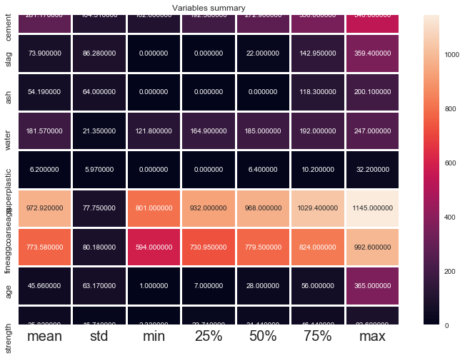

```python
plot_variables_summary(dfConcreteData)
```

```python
dfConcreteData.info()
```

```
<class 'pandas.core.frame.DataFrame'>
RangeIndex: 1030 entries, 0 to 1029
Data columns (total 9 columns):
 #   Column        Non-Null Count  Dtype
---  ------        --------------  -----
 0   cement        1030 non-null   float64
 1   slag          1030 non-null   float64
 2   ash           1030 non-null   float64
 3   water         1030 non-null   float64
 4   superplastic  1030 non-null   float64
 5   coarseagg     1030 non-null   float64
 6   fineagg       1030 non-null   float64
 7   age           1030 non-null   int64
 8   strength      1030 non-null   float64
dtypes: float64(8), int64(1)
memory usage: 72.5 KB
```

```python
# method to check null/na values
def print_null_na_values(data):
    print("Are there any null values ? : ", data.isnull().values.any())
    print("Are there any na values ?   : ", data.isna().values.any())

    print("\n")
    print("------------Checking for null ------------------")
    print(data.isnull().sum())
    print("------------Cheking for NA ---------------------")
    print(data.isna().sum())
```

```python
# Lets get null/na values if any
print_null_na_values(dfConcreteData)
```

```
Are there any null values ? :  False
Are there any na values ?   :  False


------------Checking for null ------------------
cement          0
slag            0
ash             0
water           0
superplastic    0
coarseagg       0
fineagg         0
age             0
strength        0
dtype: int64
------------Cheking for NA ---------------------
cement          0
slag            0
ash             0
water           0
superplastic    0
coarseagg       0
fineagg         0
age             0
strength        0
dtype: int64
```

### Inferences

- There are no null values
- There are no na values

```python
# method to get unique values for all columns
def uniques_values(data):
    for col in data.columns:
        print('Col Name {0}: Unique values {1}'.format(col, data[col].nunique()))
```

```python
# lets get uniques values
uniques_values(dfConcreteData)
```

```
Col Name cement: Unique values 278
Col Name slag: Unique values 185
Col Name ash: Unique values 156
Col Name water: Unique values 195
Col Name superplastic: Unique values 111
Col Name coarseagg: Unique values 284
Col Name fineagg: Unique values 302
Col Name age: Unique values 14
Col Name strength: Unique values 845
```

```python
def plot_variable_distribution(data):
    plt.figure(figsize=(15,10))
    pos=1
    for i in data.columns:
        plt.subplot(3,3,pos)
        sns.distplot(data[i])
        pos+=1
```

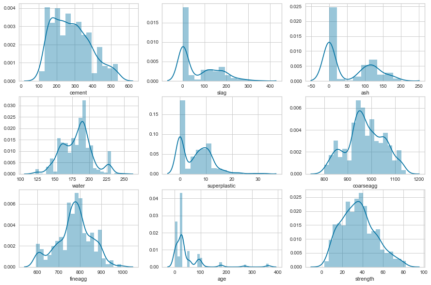

```python
plot_variable_distribution(dfConcreteData)
```

- slag is right skewed
- strength & cement have almost normal distribution

```python
# Finding outliers using Inter-Quartile Range which difference between 75th and 27th percentiles
# IQR = Q₃ − Q₁
# https://en.wikipedia.org/wiki/Interquartile_range
def findOutLiers(data):
    cols =data.columns
    outliersCols=[]
    for col in cols:
        q1 = data[col].quantile(0.25)
        q3 = data[col].quantile(0.75)
        iqr = q3-q1
        lower_range = q1-(1.5*iqr)
        upper_range = q3+(1.5*iqr)
        isOutlier = (data.loc[(data[col] < lower_range)|(data[col] > upper_range)]).empty
        if isOutlier:
            display(Markdown("There are no outliers in {0}".format(col)))#("There are no outliers in {0}".format(col))
        else:
            print('\033[91m'+ "There are outliers in column - {0}".format(col))
            outliersCols.append(col)

    print("Columns containing outliers are : {0} ".format(outliersCols))

    noOfRows=(int)(len(outliersCols)/2)
    noOfCols=2
    fig, axs = plt.subplots(nrows = noOfRows, ncols = noOfCols, figsize=(15,15))
    colIndex = 0
    for outlierCol in outliersCols:
        sns.set()
        sns.boxplot(data[outlierCol], ax = axs[math.floor(colIndex/noOfCols)][colIndex % noOfCols])
        colIndex += 1
    return outliersCols
```

There are no outliers in cement

```
There are outliers in column - slag
```

There are no outliers in ash

```
There are outliers in column - water
There are outliers in column - superplastic
```

There are no outliers in coarseagg

```
There are outliers in column - fineagg
There are outliers in column - age
There are outliers in column - strength
Columns containing outliers are : ['slag', 'water', 'superplastic', 'fineagg', 'age', 'strength']
```

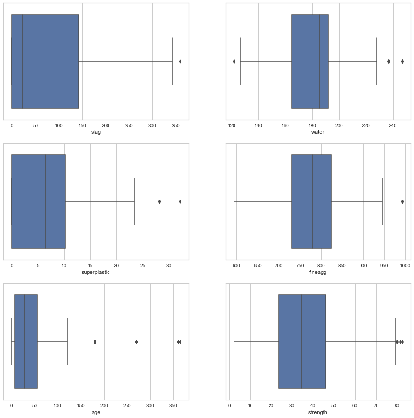

```python
# Let's find outliers
col_outliters = findOutLiers(dfConcreteData)
```

- Columns containing outliers are : ['slag', 'water', 'superplastic', 'fineagg', 'age', 'strength']

### Bivariate analysis between the predictor variables and between the predictor variables and target column.

Comment on findings in terms of their relationship and degree of relation if any. Visualize the analysis using boxplots and pair plots, histograms or density curves. (10 marks)

```python
# method to plot boxplot for univarient analysis
def plot_boxplots(data, targetColumn):
    plt.figure(figsize=(15,10))
    pos=1
    for i in data.drop(targetColumn, axis=1).columns:
        plt.subplot(3,3,pos)
        sns.boxplot(data[i])
        pos+=1
```

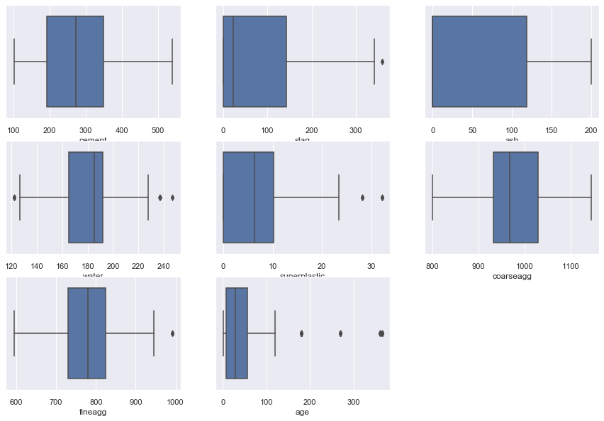

```python
plot_boxplots(dfConcreteData, 'strength') # strength is our target variable
```

```python
# plot histogram
def plot_hist(data):
    plt.figure()
    data.hist(bins=20, figsize=(15,10), color='red', )
    plt.show()
```

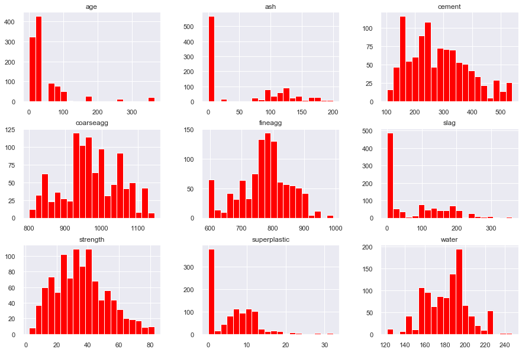

```python
plot_hist(dfConcreteData)
```

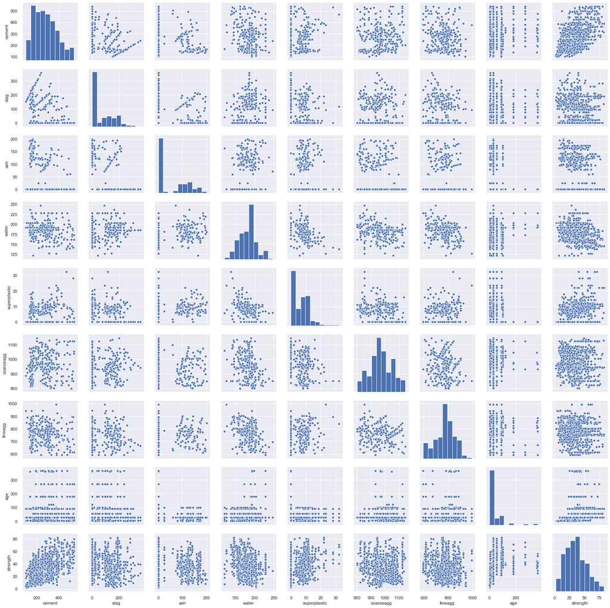

```python
sns.pairplot(dfConcreteData);
```

```python
def plot_correlation(data):
    cor = data.corr()
    plt.figure(figsize=(12,10))

    with sns.axes_style("white"):
        sns.heatmap(cor,annot=True,linewidth=2)
    plt.title("Correlation between variables")
    plt.show()
```

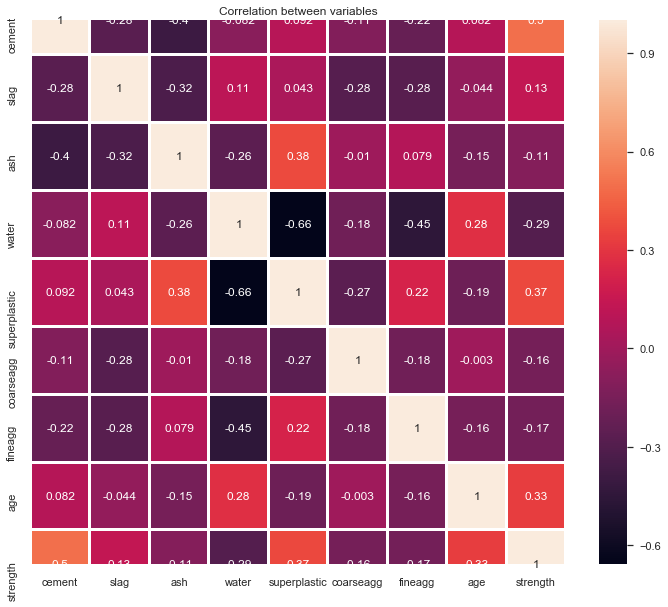

```python
plot_correlation(dfConcreteData)
```

```python
pf.ProfileReport(dfConcreteData)
```

[interactive chart not shown]

### Feature Engineering techniques

a. Identify opportunities (if any) to extract a new feature from existing features, drop a feature (if required)

b. Get data model ready and do a train test split.

c. Decide on complexity of the model, should it be simple linear model in terms of parameters or would a quadratic or higher degree.

- Remove slag & ash as they have around 50% values as zero and have weak correlation with target variable 'strength'
- A new feature can be created on 'age' but I would avoid that as of now

```python
dfConcreteLeanData = dfConcreteData.drop(['slag', 'ash'], axis=1)

col_outliters
```

```
['slag', 'water', 'superplastic', 'fineagg', 'age', 'strength']
```

```python
# treating outliers with second outliers
```

```python
col_outliters.remove('slag')
```

```python
col_outliters
```

```
['water', 'superplastic', 'fineagg', 'age', 'strength']
```

```python
for col in col_outliters:
        q1,q2,q3 = dfConcreteLeanData[col].quantile([0.25, 0.5,0.75])
        IQR = q3-q1
        a = dfConcreteLeanData[col]>q3+1.5*IQR
        b = dfConcreteLeanData[col]<q1-1.5*IQR
        dfConcreteLeanData[col]=np.where(a|b, q2, dfConcreteLeanData[col])
```

```python
x=dfConcreteLeanData.drop(['strength'], axis=1)
y=dfConcreteLeanData['strength']
```

```python
xtrain, xtest, ytrain, ytest = train_test_split(x, y, test_size=0.3, random_state=42)
```

```python
algorithmComparison = pd.DataFrame(columns=['Model','score_train', 'score_test','cv-std', 'RMSE'])
```

```python
target = "strength"
def model(model,dtrainx,dtrainy,dtestx,dtesty,of_type, algorithm_name):

    print (model)
    print ("\n")
    model.fit(dtrainx,dtrainy)
    prediction = model.predict(dtestx)
    score_train = model.score(dtrainx, dtrainy)
    score_test = model.score(dtestx, dtesty)
    print("score_train", score_train)
    print("score_test", score_test)
    print ("ROOT MEAN SQUARED ERROR :", np.sqrt(mean_squared_error(dtesty,prediction)) )
    print ("\n")
    prediction = pd.DataFrame(prediction)
    cross_val = cross_val_score(model,dtrainx,dtrainy,cv=20,scoring="neg_mean_squared_error")
    cross_val = cross_val.ravel()
    result = pd.DataFrame({'Model' : [algorithm_name], 'score_train': score_train*100,'score_test':score_test*100,'cv-std' : [cross_val.std()],
                           'RMSE' : [ np.sqrt(mean_squared_error(dtesty,prediction))]})

    return result
import warnings
warnings.filterwarnings("ignore")
```

```python
from sklearn.linear_model import LinearRegression
lr = LinearRegression()
result= model(lr,xtrain,ytrain,xtest,ytest,"coef", 'LinearRegression')
#algorithmComparison.append(result, ignore_index = True)
algorithmComparison=pd.concat([algorithmComparison, result], ignore_index=True)
```

```
LinearRegression(copy_X=True, fit_intercept=True, n_jobs=None, normalize=False)


score_train 0.6784931881345653
score_test 0.651748078072675
ROOT MEAN SQUARED ERROR : 9.24912179370075
```

```python
algorithmComparison
```

|  | Model | score_train | score_test | cv-std | RMSE |
| --- | --- | --- | --- | --- | --- |
| 0 | LinearRegression | 67.849319 | 65.174808 | 27.864484 | 9.249122 |

```python
# DecisionTreeClassifier
from sklearn.tree import DecisionTreeRegressor
dt = DecisionTreeRegressor()
result= model(dt,xtrain,ytrain,xtest,ytest,"feat", 'DecisionTreeRegressor')
#algorithmComparison.append(result, ignore_index = True)
algorithmComparison=pd.concat([algorithmComparison, result], ignore_index=True)
algorithmComparison
```

```
DecisionTreeRegressor(ccp_alpha=0.0, criterion='mse', max_depth=None,
                      max_features=None, max_leaf_nodes=None,
                      min_impurity_decrease=0.0, min_impurity_split=None,
                      min_samples_leaf=1, min_samples_split=2,
                      min_weight_fraction_leaf=0.0, presort='deprecated',
                      random_state=None, splitter='best')


score_train 0.991630485021698
score_test 0.784294919611344
ROOT MEAN SQUARED ERROR : 7.279204564638305
```

|  | Model | score_train | score_test | cv-std | RMSE |
| --- | --- | --- | --- | --- | --- |
| 0 | LinearRegression | 67.849319 | 65.174808 | 27.864484 | 9.249122 |
| 1 | DecisionTreeRegressor | 99.163049 | 78.429492 | 26.771265 | 7.279205 |

```python
# Lasso
from sklearn.linear_model import Lasso
lasso = Lasso()
lasso_result= model(lasso,xtrain,ytrain,xtest,ytest,"feat", 'Lasso')
#algorithmComparison.append(result, ignore_index = True)
algorithmComparison=pd.concat([algorithmComparison, lasso_result], ignore_index=True)
algorithmComparison
```

```
Lasso(alpha=1.0, copy_X=True, fit_intercept=True, max_iter=1000,
      normalize=False, positive=False, precompute=False, random_state=None,
      selection='cyclic', tol=0.0001, warm_start=False)


score_train 0.6783140330627175
score_test 0.6526353314730734
ROOT MEAN SQUARED ERROR : 9.237332126807766
```

|  | Model | score_train | score_test | cv-std | RMSE |
| --- | --- | --- | --- | --- | --- |
| 0 | LinearRegression | 67.849319 | 65.174808 | 27.864484 | 9.249122 |
| 1 | DecisionTreeRegressor | 99.163049 | 78.429492 | 26.771265 | 7.279205 |
| 2 | Lasso | 67.831403 | 65.263533 | 27.674923 | 9.237332 |

```python
# Ridge
from sklearn.linear_model import Ridge
ridge = Ridge()
ridge_result= model(ridge,xtrain,ytrain,xtest,ytest,"feat", 'Ridge')
#algorithmComparison.append(result, ignore_index = True)
algorithmComparison=pd.concat([algorithmComparison, ridge_result], ignore_index=True)
algorithmComparison
```

```
Ridge(alpha=1.0, copy_X=True, fit_intercept=True, max_iter=None,
      normalize=False, random_state=None, solver='auto', tol=0.001)


score_train 0.6784931881303118
score_test 0.6517484068850535
ROOT MEAN SQUARED ERROR : 9.24911742728342
```

|  | Model | score_train | score_test | cv-std | RMSE |
| --- | --- | --- | --- | --- | --- |
| 0 | LinearRegression | 67.849319 | 65.174808 | 27.864484 | 9.249122 |
| 1 | DecisionTreeRegressor | 99.163049 | 78.429492 | 26.771265 | 7.279205 |
| 2 | Lasso | 67.831403 | 65.263533 | 27.674923 | 9.237332 |
| 3 | Ridge | 67.849319 | 65.174841 | 27.864450 | 9.249117 |

```python
# RandomForestRegressor
from sklearn.ensemble import RandomForestRegressor
ramdom_forest = RandomForestRegressor()
rfr_result= model(ramdom_forest,xtrain,ytrain,xtest,ytest,"feat", 'RandomForestRegressor')
#algorithmComparison.append(result, ignore_index = True)
algorithmComparison=pd.concat([algorithmComparison, rfr_result], ignore_index=True)
```

```
RandomForestRegressor(bootstrap=True, ccp_alpha=0.0, criterion='mse',
                      max_depth=None, max_features='auto', max_leaf_nodes=None,
                      max_samples=None, min_impurity_decrease=0.0,
                      min_impurity_split=None, min_samples_leaf=1,
                      min_samples_split=2, min_weight_fraction_leaf=0.0,
                      n_estimators=100, n_jobs=None, oob_score=False,
                      random_state=None, verbose=0, warm_start=False)


score_train 0.9758833429932072
score_test 0.8470839955341232
ROOT MEAN SQUARED ERROR : 6.128867159493159
```

```python
algorithmComparison
```

|  | Model | score_train | score_test | cv-std | RMSE |
| --- | --- | --- | --- | --- | --- |
| 0 | LinearRegression | 67.849319 | 65.174808 | 27.864484 | 9.249122 |
| 1 | DecisionTreeRegressor | 99.163049 | 78.429492 | 26.771265 | 7.279205 |
| 2 | Lasso | 67.831403 | 65.263533 | 27.674923 | 9.237332 |
| 3 | Ridge | 67.849319 | 65.174841 | 27.864450 | 9.249117 |
| 4 | RandomForestRegressor | 97.588334 | 84.708400 | 21.678996 | 6.128867 |

### Model Tuning

```python
tuned_algorithmComparison = pd.DataFrame(columns=['Model','best_score'])
```

```python
# Tune the Ridge model
from sklearn.model_selection import RandomizedSearchCV
ridgeTuned = Ridge()

param_dist = {"alpha": [1, 10, 100],
              "solver": ['svd', 'sag', 'auto'],
              "normalize": [True, False]}

randomCV = RandomizedSearchCV(ridgeTuned, param_distributions=param_dist, n_jobs=4, n_iter=15)
randomCV.fit(x, y)
randomCV.best_score_
tuned_algorithmComparison.loc[0]=['ridgeTuned', randomCV.best_score_*100]
```

```python
tuned_algorithmComparison
```

|  | Model | best_score |
| --- | --- | --- |
| 0 | ridgeTuned | 65.934362 |

```python
# Tune the decision tree model
dTreeTuned = DecisionTreeRegressor()

param_dist={'criterion': ["mse", "mae"],
            'max_depth' : [3, None],
            'min_samples_leaf': sp_randint(1, 5),
            'max_features': [4, None],
            'min_samples_split': sp_randint(2, 6)}

randomCV = RandomizedSearchCV(dTreeTuned, param_distributions=param_dist, n_jobs=4, n_iter=15)
randomCV.fit(x, y)
randomCV.best_score_
tuned_algorithmComparison.loc[1]=['dTreeTuned', randomCV.best_score_*100]
```

```python
tuned_algorithmComparison
```

[output not shown]

```python
# Takes very long. The cell below has the best params that was obtained when this cell was executed. You can get the best parameters-
# by gs.best_params_

from sklearn.model_selection import GridSearchCV

grid = {'bootstrap': [True, False],
        'max_depth': [3, None],
        'max_features': ['log2', 'sqrt'],
        'min_samples_leaf': [1, 2],
        'min_samples_split': [2, 5],
        'n_estimators': [200,400]}

gs = GridSearchCV(estimator = RandomForestRegressor(random_state=1), param_grid = grid, cv = 3, n_jobs = 20, verbose = 2 )
```

```python
gs_result=model(gs,xtrain,ytrain,xtest,ytest,"coef", 'GridSearchCV_RandomForestRegressor')
gs_result
```

```
GridSearchCV(cv=3, error_score=nan,
             estimator=RandomForestRegressor(bootstrap=True, ccp_alpha=0.0,
                                             criterion='mse', max_depth=None,
                                             max_features='auto',
                                             max_leaf_nodes=None,
                                             max_samples=None,
                                             min_impurity_decrease=0.0,
                                             min_impurity_split=None,
                                             min_samples_leaf=1,
                                             min_samples_split=2,
                                             min_weight_fraction_leaf=0.0,
                                             n_estimators=100, n_jobs=None,
                                             oob_score=False, random_state=1,
                                             verbose=0, warm_start=False),
             iid='deprecated', n_jobs=20,
             param_grid={'bootstrap': [True, False], 'max_depth': [3, None],
                         'max_features': ['log2', 'sqrt'],
                         'min_samples_leaf': [1, 2],
                         'min_samples_split': [2, 5],
                         'n_estimators': [200, 400]},
             pre_dispatch='2*n_jobs', refit=True, return_train_score=False,
             scoring=None, verbose=2)


Fitting 3 folds for each of 64 candidates, totalling 192 fits
```

```
[Parallel(n_jobs=20)]: Using backend LokyBackend with 20 concurrent workers.
[Parallel(n_jobs=20)]: Done   1 tasks      | elapsed:    2.7s
[Parallel(n_jobs=20)]: Done 122 tasks      | elapsed:    9.4s
[Parallel(n_jobs=20)]: Done 192 out of 192 | elapsed:   13.1s finished
```

```
score_train 0.9916304556533713
score_test 0.8398669018683811
ROOT MEAN SQUARED ERROR : 6.271830177817473


Fitting 3 folds for each of 64 candidates, totalling 192 fits
```

[output not shown]

[output not shown]

[output not shown]

[output not shown]

[output not shown]

[output not shown]

[output not shown]

[output not shown]

[output not shown]

[output not shown]

[output not shown]

[output not shown]

[output not shown]

[output not shown]

[output not shown]

[output not shown]

[output not shown]

[output not shown]

[output not shown]

[output not shown]

[output not shown]

[output not shown]

[output not shown]

[output not shown]

[output not shown]

[output not shown]

[output not shown]

[output not shown]

[output not shown]

[output not shown]

[output not shown]

[output not shown]

[output not shown]

[output not shown]

[output not shown]

[output not shown]

[output not shown]

[output not shown]

[output not shown]

|  | Model | score_train | score_test | cv-std | RMSE |
| --- | --- | --- | --- | --- | --- |
| 0 | GridSearchCV_RandomForestRegressor | 99.163046 | 83.98669 | 19.963782 | 6.27183 |

```python
gs_result
```

|  | Model | score_train | score_test | cv-std | RMSE |
| --- | --- | --- | --- | --- | --- |
| 0 | GridSearchCV_RandomForestRegressor | 99.163046 | 83.98669 | 19.963782 | 6.27183 |

```python
tuned_algorithmComparison.loc[2]=['randomForestRegressorTuned', gs_result.score_test]
```

```python
tuned_algorithmComparison
```

|  | Model | best_score |
| --- | --- | --- |
| 0 | ridgeTuned | 65.9344 |
| 1 | dTreeTuned | 78.9591 |
| 2 | randomForestRegressorTuned | 0 83.98669 Name: score_test, dtype: float64 |

- RandomForestRegressor seems to be still best choice after tuning

## Experimental Modeling using pycaret

```python
from pycaret.utils import enable_colab
enable_colab()
```

```
Colab mode activated.
```

```python
from pycaret.regression import *
```

```python
exp_clf101 = setup(data = dfConcreteData, target = 'strength', session_id=123)
```

```
Setup Succesfully Completed!
```

|  | Description | Value |
| --- | --- | --- |
| 0 | session_id | 123 |
| 1 | Transform Target | False |
| 2 | Transform Target Method | None |
| 3 | Original Data | (1030, 9) |
| 4 | Missing Values | False |
| 5 | Numeric Features | 7 |
| 6 | Categorical Features | 1 |
| 7 | Ordinal Features | False |
| 8 | High Cardinality Features | False |
| 9 | High Cardinality Method | None |
| 10 | Sampled Data | (1030, 9) |
| 11 | Transformed Train Set | (720, 21) |
| 12 | Transformed Test Set | (310, 21) |
| 13 | Numeric Imputer | mean |
| 14 | Categorical Imputer | constant |
| 15 | Normalize | False |
| 16 | Normalize Method | None |
| 17 | Transformation | False |
| 18 | Transformation Method | None |
| 19 | PCA | False |
| 20 | PCA Method | None |
| 21 | PCA Components | None |
| 22 | Ignore Low Variance | False |
| 23 | Combine Rare Levels | False |
| 24 | Rare Level Threshold | None |
| 25 | Numeric Binning | False |
| 26 | Remove Outliers | False |
| 27 | Outliers Threshold | None |
| 28 | Remove Multicollinearity | False |
| 29 | Multicollinearity Threshold | None |
| 30 | Clustering | False |
| 31 | Clustering Iteration | None |
| 32 | Polynomial Features | False |
| 33 | Polynomial Degree | None |
| 34 | Trignometry Features | False |
| 35 | Polynomial Threshold | None |
| 36 | Group Features | False |
| 37 | Feature Selection | False |
| 38 | Features Selection Threshold | None |
| 39 | Feature Interaction | False |
| 40 | Feature Ratio | False |
| 41 | Interaction Threshold | None |

```python
compare_models()
```

|  | Model | MAE | MSE | RMSE | R2 | RMSLE | MAPE |
| --- | --- | --- | --- | --- | --- | --- | --- |
| 0 | CatBoost Regressor | 3.244600 | 23.430100 | 4.778200 | 0.912000 | 0.153500 | 0.113900 |
| 1 | Light Gradient Boosting Machine | 3.690400 | 31.258300 | 5.490100 | 0.882600 | 0.174100 | 0.131700 |
| 2 | Extra Trees Regressor | 3.606600 | 32.529600 | 5.643700 | 0.877700 | 0.171200 | 0.124500 |
| 3 | Random Forest | 3.940700 | 33.099000 | 5.704400 | 0.876100 | 0.179100 | 0.139200 |
| 4 | Gradient Boosting Regressor | 4.495100 | 37.105500 | 6.061400 | 0.861500 | 0.185900 | 0.153200 |
| 5 | Extreme Gradient Boosting | 4.557800 | 38.024600 | 6.134300 | 0.858800 | 0.190200 | 0.156200 |
| 6 | Linear Regression | 5.456700 | 49.604700 | 7.005500 | 0.818000 | 0.240700 | 0.188800 |
| 7 | Bayesian Ridge | 5.464200 | 49.867700 | 7.021700 | 0.817100 | 0.239500 | 0.189800 |
| 8 | Ridge Regression | 5.481000 | 50.556600 | 7.066900 | 0.814600 | 0.240400 | 0.191900 |
| 9 | Random Sample Consensus | 5.533400 | 55.044300 | 7.379200 | 0.797700 | 0.238600 | 0.187300 |
| 10 | TheilSen Regressor | 5.694600 | 59.824200 | 7.644500 | 0.782300 | 0.248400 | 0.199000 |
| 11 | Decision Tree | 4.982100 | 58.520100 | 7.516700 | 0.780400 | 0.223300 | 0.162900 |
| 12 | AdaBoost Regressor | 7.802800 | 90.329000 | 9.455300 | 0.667900 | 0.346800 | 0.339900 |
| 13 | Lasso Regression | 8.012600 | 101.923800 | 10.012700 | 0.628500 | 0.321800 | 0.303200 |
| 14 | Huber Regressor | 8.179700 | 109.774000 | 10.303100 | 0.604100 | 0.338600 | 0.318000 |
| 15 | Elastic Net | 9.595700 | 142.462500 | 11.863500 | 0.478400 | 0.397100 | 0.393100 |
| 16 | K Neighbors Regressor | 9.748800 | 151.939700 | 12.285600 | 0.433600 | 0.413600 | 0.401200 |
| 17 | Orthogonal Matching Pursuit | 10.102400 | 164.083700 | 12.774300 | 0.391000 | 0.399100 | 0.390000 |
| 18 | Passive Aggressive Regressor | 11.003900 | 187.474100 | 13.552200 | 0.313400 | 0.435200 | 0.407700 |
| 19 | Support Vector Machine | 12.366300 | 236.163100 | 15.303300 | 0.136700 | 0.501400 | 0.545100 |
| 20 | Lasso Least Angle Regression | 13.466100 | 279.081200 | 16.646100 | -0.022100 | 0.540500 | 0.608900 |
| 21 | Least Angle Regression | 278.112700 | 1195278.178600 | 356.212900 | -5257.133500 | 0.789000 | 10.112000 |

- This suggests CatBoost Regressor our initial assesment about random forest is also not wrong
- Random Forest score 87.610